# Laboratorio 1.2: Exploración y Visualización de Datos

Millaray Valdivia Saldias, Ignacio Díaz Lara

Septiembre 2021

# Declaración de compromiso ético

# Instrucciones

1. Trabajen en equipos de dos personas. Salvo excepciones, no se corregirá entregas con menos de dos integrantes.
2. Modifique este archivo `.Rmd` agregando sus respuestas donde corresponda.
3. Para cada pregunta, cuando corresponda, **incluya el código fuente que utilizó para llegar a su respuesta**.
4. El formato de entrega para esta actividad es un archivo html. **Genere un archivo HTML usando RStudio** y súbalo a U-Cursos.

Basta con que uno de los integrantes haga la entrega. Si ambos hacen una entrega en U-Cursos, se revisará cualquiera de éstas.

# Laboratorio

La primera parte de esta actividad son preguntas teóricas que avanzaron en las clases del curso de Minería de datos.

## Teoría

*1. Respecto a los tipos de atributo, ¿cuál es la diferencia entre razón e intervalo? De un ejemplo.*

**Respuesta: La razón parte desde un cero absoluto y puede multiplicarse y divirse, mientras que el intervalo puede sumarse y restarse. Ejemplo los grados kelvin parten de un cero absoluto y no tiene números negativos, mientras que los grados celsius tienen un cero arbitrario por lo que puede tener números positivos y negativos.**

*2. ¿Qué factores que ocasionan errores en el análisis de datos deben ser considerados para la limpieza de un set de datos?*

**Respuesta: Ruido, outliers, datos faltantes, datos duplicados y sesgo.**

*3. Describa las medidas de tendencia central: media y mediana. Exponga la diferencia entre ambas.*

**Respuesta: La mediana es la que representa la posición central de las variables, separando la mitad inferior y la mitad superior de las observaciones. La media es el promedio o media aritmética para m valores. Dentro de las diferencias que podemos encontrar está que la media es más sensible a los outliers (y otros ruidos) que la mediana**

*4. ¿Qué es una matriz de correlación y para qué sirve?*

**Respuesta: Una matriz de correlación es un gráfico donde se puede ver como se relaciona cada par de atributos del data-frame y sirve para ver cuales variables tienen mayor relación e influyen más en otras y así distinguir patrones en los datos.**

*5. Explique el principio de Bonferroni y su utilidad.*

**Respuesta: El principio de Bonferroni indica que si se busca mucho más de lo que la cantidad de datos permiten se puede encontrar basura. Así, se podría creer que se probó una hipótesis con falsos positivos o correlaciones que no implican causalidad. Se utiliza para encontrar un límite superior en la precisión de los métodos utilizados.**

## Práctica

Para esta sección utilizaremos un dataset real de número de accidentes de tránsito por localidad, el cual puede ser encontrado en el siguiente link: http://datos.gob.cl/dataset/9348. Para cargar el dataset ejecute el siguiente código:

```r
tipos <- read.table("https://users.dcc.uchile.cl/~hsarmien/mineria/datasets/accidentes_2010_2011.txt", encoding = "UTF-8")
head(tipos)
```

```
##    Muestra                  Descripcion Anio TipoAccidente Cantidad
## 1 Nacional                     Nacional 2010     Atropello     8247
## 2 Nacional                     Nacional 2011     Atropello     8339
## 3 Regional XV Región Arica y Parinacota 2010     Atropello      115
## 4 Regional XV Región Arica y Parinacota 2011     Atropello      159
## 5  Comunal                        ARICA 2010     Atropello      115
## 6  Comunal                        ARICA 2011     Atropello      158
```

```r
# agregamos el encoding por los símbolos
```

Explore el set de datos para responder las siguientes preguntas:

1. ¿Cuáles son las dimensiones del dataset (filas, columnas)? (Recuerde adjuntar código).

```r
dim(tipos)
```

```
## [1] 4296    5
```

2. ¿Qué describe cada línea del dataset? (ejemplifique tomando el dato de la fila 235, extienda la descripción)

```r
tipos[235, ]
```

```
##     Muestra Descripcion Anio TipoAccidente Cantidad
## 235 Comunal    PALMILLA 2010     Atropello        4
```

```r
# De esto podemos inferir que el dataset describe la cantidad de accidentes y el tipo de estos, según año en una locación que lleva el nombre de Descripción, y el tipo de la locación que lleva el nombre de muestra.
```

3. Filtre los datos y genere un dataframe en el cual se indique la cantidad de accidentes tipo `Colision` que hubo en el año `2011`.

```r
library(tidyverse)
colision2011 <- tipos %>%
  filter(Anio == 2011 & TipoAccidente == "Colision") %>%  # filtra por año 2011 y tipo de accidente colisión
  group_by(TipoAccidente) %>%  # agrupa por el tipo de accidente
  summarise(total_2011 = sum(Cantidad))  #suma los accidentes agrupados en el tipo de accidente
colision2011
```

```
## # A tibble: 1 x 2
##   TipoAccidente total_2011
##   <chr>              <int>
## 1 Colision           94461
```

4. Filtre los datos para incluir sólo los accidentes ocurridos el año 2010 a nivel regional. Genere un boxplot donde se indique la cantidad de accidentes categorizado por tipo de accidente.

Este tipo de gráfico nos ayudará a entender como se distribuye los datos por cada tipo de accidentes. Es decir, podremos apreciar que tan dispersos o similares son los datos en todo el dataset. También, puede ser útil para observar valores atípicos u outliers en los datos.

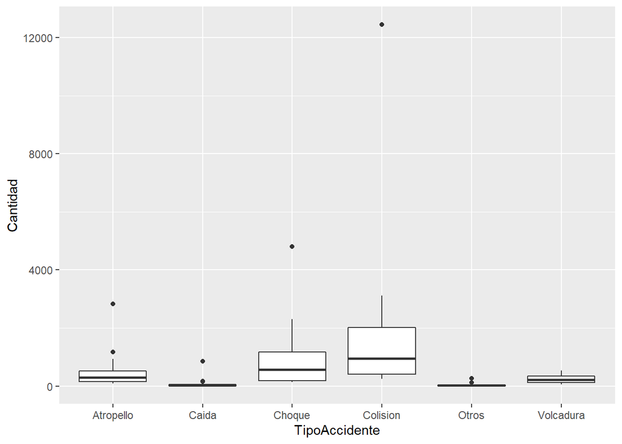

```r
library(ggplot2)
tipos_reg <- with(tipos, tipos[Anio == 2010 & Muestra == "Regional", ]) #  filtro por año 2010 y muestra regional
ggplot(tipos_reg, aes(x = TipoAccidente, y= Cantidad)) +
  geom_boxplot()  # genera el plot con boxplot
```

5. ¿Qué otra forma de explorar los datos podría agregar para el dataset de Accidentes de tránsito y qué información adicional aporta? Adjunte el código necesario.

```r
accidentes_por_comuna <- tipos %>%
  filter(Muestra == "Comunal") %>%   #filtra por muestra comunal
  group_by(Descripcion) %>%   # agrupa por descripción
  summarise(total = sum(Cantidad)) %>%  # suma la cantidad de accidentes agrupadas por descripción
  arrange(-total)  # ordena decrecientemente el total

accidentes_por_region <- tipos %>%
  filter(Muestra == "Regional") %>%   #filtra por muestra regional
  group_by(Descripcion) %>%   # agrupa por descripción
  summarise(total = sum(Cantidad)) %>%  # suma la cantidad de accidentes agrupadas por descripción
  arrange(-total)  # ordena decrecientemente el total


accidentes_por_region
```

```
## # A tibble: 16 x 2
##    Descripcion                       total
##    <chr>                             <int>
##  1 Región Metropolitana              45195
##  2 V Región de Valparaíso            14747
##  3 VII Región del Maule               8931
##  4 IX Región de la Araucanía          7499
##  5 VI Región del Lib. Bdo. O´Higgins  6950
##  6 VII Región del Bio-Bio             6643
##  7 VIII Región del Bio-Bio            6128
##  8 X Región de Los Lagos              5550
##  9 IV Región de Coquimbo              4240
## 10 II Región de Antofagasta           4124
## 11 XII Región de Magallanes           2279
## 12 XIV Región de Los Ríos             2173
## 13 I Región de Tarapacá               1870
## 14 XV Región Arica y Parinacota       1616
## 15 III Región de Atacama              1419
## 16 XI Región de Aysén                 1216
```

```r
accidentes_por_comuna
```

```
## # A tibble: 342 x 2
##    Descripcion total
##    <chr>       <int>
##  1 SANTIAGO     4898
##  2 RANCAGUA     3821
##  3 TEMUCO       3810
##  4 PUENTE ALTO  3601
##  5 VALPARAISO   3189
##  6 MAIPU        3173
##  7 ANTOFAGASTA  2811
##  8 LA FLORIDA   2567
##  9 CONCEPCION   2287
## 10 LA SERENA    2277
## # ... with 332 more rows
```

```r
# Estas tablas entregan información adicional al mostrar qué comunas y qué regiones son las que tienen más accidentes. Gracias a esto, podemos ver, por ejemplo, que hay comunas como Santiago o Rancagua que tienen más accidentes que regiones enteras, como la Región de Atacama o Aysén.
```

### Diamantes

Considere el set de datos diamonds del paquete ggplot2 de R, que contiene los precios en dolares, junto con otros atributos importantes: quilates, corte, color y claridad. También hay medidas físicas como ser: x (largo), y (ancho), z (profundidad), depth (porcentaje total de profundidad) y table (ancho desde el tope del diamante al punto relativo más ancho del diamante):

```r
library(ggplot2)
data("diamonds")
head(diamonds)
```

```
## # A tibble: 6 x 10
##   carat cut       color clarity depth table price     x     y     z
##   <dbl> <ord>     <ord> <ord>   <dbl> <dbl> <int> <dbl> <dbl> <dbl>
## 1  0.23 Ideal     E     SI2      61.5    55   326  3.95  3.98  2.43
## 2  0.21 Premium   E     SI1      59.8    61   326  3.89  3.84  2.31
## 3  0.23 Good      E     VS1      56.9    65   327  4.05  4.07  2.31
## 4  0.29 Premium   I     VS2      62.4    58   334  4.2   4.23  2.63
## 5  0.31 Good      J     SI2      63.3    58   335  4.34  4.35  2.75
## 6  0.24 Very Good J     VVS2     62.8    57   336  3.94  3.96  2.48
```

Realice una exploración por el set de datos para responder las siguientes preguntas:

1. Teniendo en cuenta las medidas físicas, ¿considera que existen valores inexistentes o inconsistentes? Describa como manejaría esta situación. Adjunte el código necesario.

```r
# Existen valores inexistentes tales como diamantes que miden (0, 0, 0), e inconsistentes ya que a pesar de tener ciertas medidas iguales a 0, tienen un valor de profundidad que no lo es. Esto se puede manejar eliminando estos datos filtrando la tabla 'diamonds', ya que si se quieren estudiar los datos desde el punto de vista físico, esto solo genera basura y no aportan al estudio.
diamonds2 <- diamonds %>%
  filter(x != 0 & y != 0 & z != 0)%>%
  arrange(z)
diamonds2
```

```
## # A tibble: 53,920 x 10
##    carat cut       color clarity depth table price     x     y     z
##    <dbl> <ord>     <ord> <ord>   <dbl> <dbl> <int> <dbl> <dbl> <dbl>
##  1  1.07 Ideal     F     SI1      60.6    57  5909  6.62  6.67  1.07
##  2  1.41 Ideal     H     VS1      60.7    56  9752  7.31  7.22  1.41
##  3  1.53 Ideal     I     SI1      61.9    54  8971  7.43  7.5   1.53
##  4  0.38 Ideal     E     VVS2     60.9    56  1068  4.71  4.68  2.06
##  5  0.2  Premium   E     VS2      59      60   367  3.81  3.78  2.24
##  6  0.55 Very Good E     VS2      61      59  1831  5.31  5.34  2.25
##  7  0.2  Premium   E     VS2      59.8    62   367  3.79  3.77  2.26
##  8  0.2  Premium   E     SI2      60.2    62   345  3.79  3.75  2.27
##  9  0.2  Premium   E     VS2      59.7    62   367  3.84  3.8   2.28
## 10  0.21 Premium   D     VS2      59.1    62   386  3.89  3.86  2.29
## # ... with 53,910 more rows
```

2. Considere la relación entre dos atributos y adjunte el código necesario para las respuestas:
- ¿Qué atributos están más correlacionadas con precio (price) y qué significa esto?
- ¿Cuál es la correlación más alta para table?

```r
# Sacamos el coeficiente de correlación de Pearson entre table, price con todas las columnas numéricas del dataset.
cor(diamonds[,6:7], diamonds[,5:10])
```

```
##            depth     table     price         x         y         z
## table -0.2957785 1.0000000 0.1271339 0.1953443 0.1837601 0.1509287
## price -0.0106474 0.1271339 1.0000000 0.8844352 0.8654209 0.8612494
```

```r
cor(diamonds[,6:7], diamonds[,1])
```

```
##           carat
## table 0.1816175
## price 0.9215913
```

```r
# Con estos resultados podemos concluir que el precio está más correlacionado linealmente con carat que son los quilates (0.9215913). Por lo tanto, mientras más quilates más alto el precio.

# Y también que la variable table (que representa el ancho desde el tope del diamante al punto relativo más ancho del diamante) está más correlacionado linealmente con x (0.1953443). A pesar de ser una correlación más baja, tiene sentido que una medida del ancho del diamente se relacione con una medida de longitud del diamante.
```

3. Proponga otra forma para explorar los datos. ¿Qué información adicional aporta? Adjunte una breve explicación.

**Respuesta: Proponemos agregar una variable volumen que multiplique las columnas x,y,z. Esto podría agregar información sobre el tamaño más general del diamante y cómo se relaciona con las otras columnas no físicas, como el precio.**